# Analisis Revenue dan Segmentasi Pelanggan pada Database Sakila

Fikri Adhiatma Nugroho

2026-05-26

# 📊 Analisis Revenue & Segmentasi Pelanggan

Studi Kasus Database Sakila — Toko Rental DVD

# 1 Pendahuluan

Database Sakila merupakan contoh database relasional yang dikembangkan oleh MySQL, merepresentasikan sistem informasi toko rental DVD. Analisis ini bertujuan untuk mengeksplorasi dua insight utama: **(1)** tren dan perbandingan revenue antar toko, serta **(2)** segmentasi pelanggan berdasarkan perilaku transaksi menggunakan metode K-Means Clustering.

# 2 Tujuan Analisis

Analisis ini memiliki empat tujuan utama:

1. Mengidentifikasi tren revenue bulanan toko rental DVD Sakila sepanjang periode transaksi yang tersedia.
2. Membandingkan performa revenue antara Store 1 dan Store 2 untuk mengetahui apakah terdapat perbedaan kontribusi yang signifikan antar toko.
3. Menguji pengaruh frekuensi rental terhadap total spending pelanggan menggunakan analisis regresi linear sederhana.
4. Mengelompokkan pelanggan ke dalam segmen-segmen berdasarkan perilaku transaksinya menggunakan metode K-Means Clustering.

# 3 Tahapan Analisis

Analisis ini dilakukan melalui beberapa tahapan yang sistematis, yaitu:

1. **Persiapan** — Memuat library yang dibutuhkan dan membuat koneksi ke database Sakila melalui MySQL.
2. **Pengambilan Data** — Mengambil data dari database menggunakan query SQL untuk membentuk tiga dataset utama.
3. **Exploratory Data Analysis (EDA)** — Memeriksa kualitas data meliputi missing values, duplikasi, tipe data, nilai tidak wajar, dan outlier.
4. **Preprocessing Data** — Mengonversi tipe data, menghitung variabel recency, dan menormalisasi data untuk keperluan clustering.
5. **Visualisasi Data** — Membuat visualisasi grafis untuk mengeksplorasi pola dan tren dalam data.
6. **Analisis Statistik** — Melakukan statistik deskriptif, regresi linear sederhana, dan K-Means Clustering.
7. **Kesimpulan** — Merangkum temuan utama dan memberikan rekomendasi bisnis berdasarkan hasil analisis.

## 3.1 Persiapan

```r
library(RMySQL)
library(DBI)
library(dplyr)
library(ggplot2)
library(lubridate)
library(scales)
library(cluster)
library(factoextra)
library(knitr)
library(kableExtra)
```

### 3.1.1 Koneksi Database

```r
con <- dbConnect(
  RMySQL::MySQL(),
  dbname   = "sakila",
  host     = "127.0.0.1",
  port     = 3306,
  user     = "root",
  password = "nasipadanggg"
)

dbListTables(con)
```

```
##  [1] "actor"                      "actor_info"
##  [3] "address"                    "category"
##  [5] "city"                       "country"
##  [7] "customer"                   "customer_list"
##  [9] "film"                       "film_actor"
## [11] "film_category"              "film_list"
## [13] "film_text"                  "inventory"
## [15] "language"                   "nicer_but_slower_film_list"
## [17] "payment"                    "rental"
## [19] "sales_by_film_category"     "sales_by_store"
## [21] "staff"                      "staff_list"
## [23] "store"
```

## 3.2 Pengambilan Data

Tiga dataset utama diambil langsung dari database Sakila menggunakan query SQL. Dataset pertama berisi agregasi revenue per bulan (`df_revenue`), dataset kedua memisahkan revenue per toko per bulan (`df_toko`), dan dataset ketiga mengambil data perilaku transaksi per pelanggan sebagai bahan segmentasi (`df_customer`).

```r
# ── 1. Revenue per bulan ──────────────────────────────────────────
df_revenue <- dbGetQuery(con, "
  SELECT
    DATE_FORMAT(payment_date, '%Y-%m') AS bulan,
    SUM(amount)                        AS total_revenue,
    COUNT(payment_id)                  AS jumlah_transaksi
  FROM payment
  GROUP BY bulan
  ORDER BY bulan;
")

# ── 2. Revenue per toko per bulan ─────────────────────────────────
df_toko <- dbGetQuery(con, "
  SELECT
    DATE_FORMAT(p.payment_date, '%Y-%m') AS bulan,
    s.store_id,
    SUM(p.amount)                        AS total_revenue,
    COUNT(p.payment_id)                  AS jumlah_transaksi
  FROM payment p
  JOIN rental r    ON p.rental_id    = r.rental_id
  JOIN inventory i ON r.inventory_id = i.inventory_id
  JOIN store s     ON i.store_id     = s.store_id
  GROUP BY bulan, s.store_id
  ORDER BY bulan, s.store_id;
")

# ── 3. Segmentasi pelanggan ───────────────────────────────────────
df_customer <- dbGetQuery(con, "
  SELECT
    p.customer_id,
    CONCAT(c.first_name, ' ', c.last_name) AS nama,
    COUNT(p.payment_id)                    AS frekuensi,
    SUM(p.amount)                          AS total_spending,
    MAX(p.payment_date)                    AS last_payment
  FROM payment p
  JOIN customer c ON p.customer_id = c.customer_id
  GROUP BY p.customer_id, nama
  ORDER BY total_spending DESC;
")

head(df_revenue)
```

```
##     bulan total_revenue jumlah_transaksi
## 1 2005-05       4823.44             1156
## 2 2005-06       9629.89             2311
## 3 2005-07      28368.91             6709
## 4 2005-08      24070.14             5686
## 5 2006-02        514.18              182
```

```r
head(df_toko)
```

```
##     bulan store_id total_revenue jumlah_transaksi
## 1 2005-05        1       2459.25              575
## 2 2005-05        2       2364.19              581
## 3 2005-06        1       4734.79             1121
## 4 2005-06        2       4895.10             1190
## 5 2005-07        1      14308.66             3334
## 6 2005-07        2      14060.25             3375
```

```r
head(df_customer)
```

```
##   customer_id           nama frekuensi total_spending        last_payment
## 1         526      KARL SEAL        45         221.55 2005-08-23 22:21:03
## 2         148   ELEANOR HUNT        46         216.54 2005-08-23 05:57:04
## 3         144     CLARA SHAW        42         195.58 2005-08-23 12:43:30
## 4         137 RHONDA KENNEDY        39         194.61 2005-08-23 21:56:04
## 5         178  MARION SNYDER        39         194.61 2006-02-14 15:16:03
## 6         459  TOMMY COLLAZO        38         186.62 2005-08-23 14:52:50
```

## 3.3 Exploratory Data Analysis (EDA)

Sebelum preprocessing, dilakukan pengecekan kualitas data mencakup missing values, duplikasi, tipe data, nilai tidak wajar, dan outlier pada ketiga dataset.

```r
# ── 1. Missing Values ─────────────────────────────────────────────
bind_rows(
  df_revenue  %>% summarise(across(everything(), ~sum(is.na(.)))) %>% mutate(dataset = "df_revenue"),
  df_toko     %>% summarise(across(everything(), ~sum(is.na(.)))) %>% mutate(dataset = "df_toko"),
  df_customer %>% summarise(across(everything(), ~sum(is.na(.)))) %>% mutate(dataset = "df_customer")
) %>% select(dataset, everything()) %>%
  kable(caption = "Pengecekan Missing Values") %>%
  kable_styling(bootstrap_options = c("striped", "hover", "condensed"), full_width = FALSE)
```

Pengecekan Missing Values

| dataset | bulan | total_revenue | jumlah_transaksi | store_id | customer_id | nama | frekuensi | total_spending | last_payment |
| --- | --- | --- | --- | --- | --- | --- | --- | --- | --- |
| df_revenue | 0 | 0 | 0 | NA | NA | NA | NA | NA | NA |
| df_toko | 0 | 0 | 0 | 0 | NA | NA | NA | NA | NA |
| df_customer | NA | NA | NA | NA | 0 | 0 | 0 | 0 | 0 |

```r
# ── 2. Duplikasi ──────────────────────────────────────────────────
data.frame(
  Dataset   = c("df_revenue", "df_toko", "df_customer"),
  Duplikasi = c(sum(duplicated(df_revenue)),
                sum(duplicated(df_toko)),
                sum(duplicated(df_customer)))
) %>%
  kable(caption = "Pengecekan Duplikasi") %>%
  kable_styling(bootstrap_options = c("striped", "hover", "condensed"), full_width = FALSE)
```

Pengecekan Duplikasi

| Dataset | Duplikasi |
| --- | --- |
| df_revenue | 0 |
| df_toko | 0 |
| df_customer | 0 |

```r
# ── 3. Nilai Tidak Wajar ──────────────────────────────────────────
data.frame(
  Variabel           = c("total_revenue", "jumlah_transaksi", "total_spending", "frekuensi"),
  Nilai_Negatif      = c(sum(df_revenue$total_revenue <= 0),
                         sum(df_revenue$jumlah_transaksi <= 0),
                         sum(df_customer$total_spending <= 0),
                         sum(df_customer$frekuensi <= 0))
) %>%
  kable(caption = "Pengecekan Nilai Tidak Wajar") %>%
  kable_styling(bootstrap_options = c("striped", "hover", "condensed"), full_width = FALSE)
```

Pengecekan Nilai Tidak Wajar

| Variabel | Nilai_Negatif |
| --- | --- |
| total_revenue | 0 |
| jumlah_transaksi | 0 |
| total_spending | 0 |
| frekuensi | 0 |

```r
# ── 4. Outlier (IQR Method) ───────────────────────────────────────
outlier_df <- function(x, nama) {
  Q1  <- quantile(x, 0.25)
  Q3  <- quantile(x, 0.75)
  IQR_val     <- Q3 - Q1
  batas_bawah <- Q1 - 1.5 * IQR_val
  batas_atas  <- Q3 + 1.5 * IQR_val
  data.frame(
    Variabel      = nama,
    Q1            = round(Q1, 2),
    Q3            = round(Q3, 2),
    Batas_Bawah   = round(batas_bawah, 2),
    Batas_Atas    = round(batas_atas, 2),
    Jumlah_Outlier = sum(x < batas_bawah | x > batas_atas)
  )
}

bind_rows(
  outlier_df(df_customer$frekuensi,      "frekuensi"),
  outlier_df(df_customer$total_spending, "total_spending")
) %>%
  kable(caption = "Pengecekan Outlier (Metode IQR)") %>%
  kable_styling(bootstrap_options = c("striped", "hover", "condensed"), full_width = FALSE)
```

Pengecekan Outlier (Metode IQR)

|  | Variabel | Q1 | Q3 | Batas_Bawah | Batas_Atas | Jumlah_Outlier |
| --- | --- | --- | --- | --- | --- | --- |
| 25%…1 | frekuensi | 23.00 | 30.0 | 12.50 | 40.50 | 6 |
| 25%…2 | total_spending | 94.78 | 128.7 | 43.91 | 179.58 | 6 |

```r
# ── 5. Dimensi Data ───────────────────────────────────────────────
data.frame(
  Dataset = c("df_revenue", "df_toko", "df_customer"),
  Baris   = c(nrow(df_revenue), nrow(df_toko), nrow(df_customer)),
  Kolom   = c(ncol(df_revenue), ncol(df_toko), ncol(df_customer))
) %>%
  kable(caption = "Dimensi Dataset") %>%
  kable_styling(bootstrap_options = c("striped", "hover", "condensed"), full_width = FALSE)
```

Dimensi Dataset

| Dataset | Baris | Kolom |
| --- | --- | --- |
| df_revenue | 5 | 3 |
| df_toko | 10 | 4 |
| df_customer | 599 | 5 |

Berdasarkan hasil EDA, diperoleh beberapa temuan penting. **Missing values** tidak ditemukan pada ketiga dataset, menunjukkan bahwa data dari database Sakila sudah lengkap. **Duplikasi** juga tidak ditemukan, artinya setiap baris merupakan record yang unik. Dari sisi **tipe data**, kolom `bulan` dan `last_payment` masih bertipe `character` dan akan dikonversi pada tahap preprocessing. **Nilai tidak wajar** seperti angka negatif tidak ditemukan pada seluruh variabel numerik. Terkait **outlier**, ditemukan masing-masing 6 outlier pada variabel `frekuensi` dan `total_spending` menggunakan metode IQR dengan batas $Q3 + 1.5 \times IQR$. Outlier ini **tidak dihapus** karena merepresentasikan pelanggan dengan aktivitas sangat tinggi yang justru relevan untuk analisis segmentasi.

## 3.4 Preprocessing Data

Kolom `bulan` dikonversi ke format `Date`, `store_id` diubah menjadi faktor berlabel, dan `last_payment` dikonversi ke `POSIXct`. Variabel `recency` dihitung sebagai selisih hari dari transaksi terakhir pelanggan ke tanggal transaksi terbaru dalam data. Ketiga variabel clustering kemudian dinormalisasi menggunakan `scale()` agar tidak ada variabel yang mendominasi karena perbedaan skala.

```r
# ── 1. Revenue per bulan ──────────────────────────────────────────
df_revenue <- df_revenue %>%
  mutate(
    bulan          = as.Date(paste0(bulan, "-01")),
    rata_transaksi = total_revenue / jumlah_transaksi
  )

# ── 2. Data toko ──────────────────────────────────────────────────
df_toko <- df_toko %>%
  mutate(
    bulan    = as.Date(paste0(bulan, "-01")),
    store_id = factor(store_id, labels = c("Store 1", "Store 2"))
  )

# ── 3. Data customer ──────────────────────────────────────────────
df_customer <- df_customer %>%
  mutate(last_payment = as.POSIXct(last_payment))

tgl_max <- max(df_customer$last_payment)

df_customer <- df_customer %>%
  mutate(
    recency = as.numeric(difftime(tgl_max, last_payment, units = "days"))
  )

# ── 4. Normalisasi untuk clustering ──────────────────────────────
df_cluster <- df_customer %>%
  select(frekuensi, total_spending, recency) %>%
  scale() %>%
  as.data.frame()

glimpse(df_customer)
```

```
## Rows: 599
## Columns: 6
## $ customer_id    <dbl> 526, 148, 144, 137, 178, 459, 469, 468, 236, 181, 176, …
## $ nama           <chr> "KARL SEAL", "ELEANOR HUNT", "CLARA SHAW", "RHONDA KENN…
## $ frekuensi      <dbl> 45, 46, 42, 39, 39, 38, 40, 39, 42, 34, 37, 35, 32, 33,…
## $ total_spending <dbl> 221.55, 216.54, 195.58, 194.61, 194.61, 186.62, 177.60,…
## $ last_payment   <dttm> 2005-08-23 22:21:03, 2005-08-23 05:57:04, 2005-08-23 1…
## $ recency        <dbl> 174.7049, 175.3882, 175.1059, 174.7222, 0.0000, 175.016…
```

```r
summary(df_cluster)
```

```
##    frekuensi       total_spending        recency
##  Min.   :-2.8931   Min.   :-2.43169   Min.   :-1.6692
##  1st Qu.:-0.7406   1st Qu.:-0.69964   1st Qu.:-1.6692
##  Median :-0.1535   Median :-0.07103   Median : 0.5905
##  Mean   : 0.0000   Mean   : 0.00000   Mean   : 0.0000
##  3rd Qu.: 0.6292   3rd Qu.: 0.63760   3rd Qu.: 0.5992
##  Max.   : 3.7601   Max.   : 4.29784   Max.   : 0.6756
```

Setelah preprocessing, kolom `bulan` berhasil dikonversi ke format `Date` dan `store_id` menjadi faktor berlabel. Variabel `recency` berhasil dihitung dengan rentang 0 hingga 181,6 hari. Hasil `summary(df_cluster)` menunjukkan ketiga variabel sudah ternormalisasi dengan mean = 0 dan skala yang sebanding, sehingga proses clustering tidak akan didominasi oleh satu variabel tertentu.

## 3.5 Visualisasi Data

Tiga visualisasi dibuat untuk mengeksplorasi data secara visual. *Line chart* digunakan untuk melihat tren revenue dari waktu ke waktu. *Bar chart grouped* digunakan untuk membandingkan kontribusi revenue Store 1 vs Store 2 per bulan. *Scatter plot* dengan garis regresi digunakan untuk melihat pola hubungan antara frekuensi rental dan total spending pelanggan.

### 3.5.1 Tren Revenue per Bulan

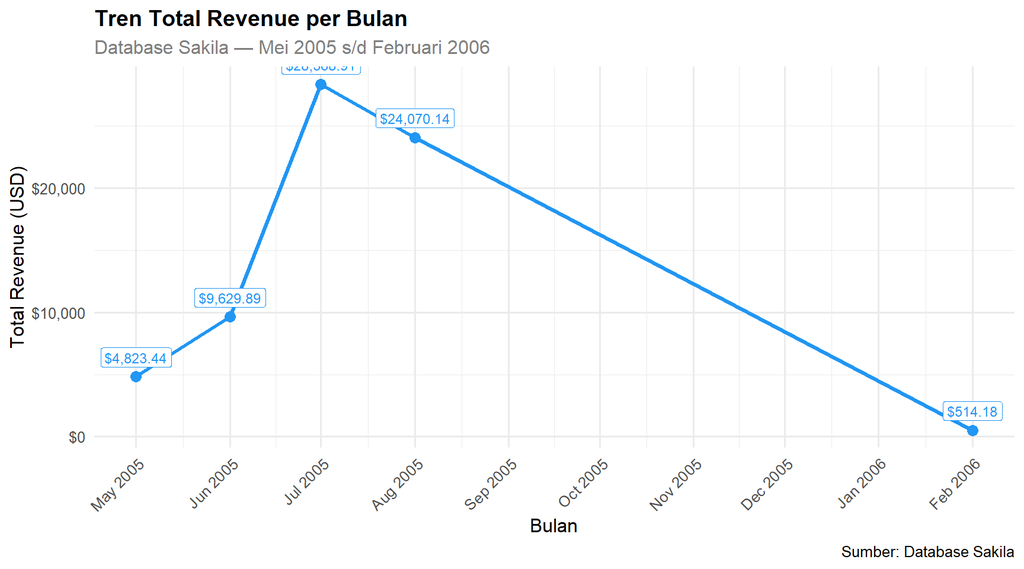

Tren Revenue per Bulan

```r
ggplot(df_revenue, aes(x = bulan, y = total_revenue)) +
  geom_line(color = "#2196F3", linewidth = 1.2) +
  geom_point(color = "#2196F3", size = 3) +
  geom_label(aes(label = dollar(total_revenue, prefix = "$")),
             vjust = -0.5, size = 3.2, fill = "white", color = "#2196F3") +
  scale_y_continuous(labels = dollar_format(prefix = "$")) +
  scale_x_date(date_labels = "%b %Y", date_breaks = "1 month") +
  labs(
    title    = "Tren Total Revenue per Bulan",
    subtitle = "Database Sakila — Mei 2005 s/d Februari 2006",
    x        = "Bulan",
    y        = "Total Revenue (USD)",
    caption  = "Sumber: Database Sakila"
  ) +
  theme_minimal(base_size = 12) +
  theme(
    plot.title    = element_text(face = "bold", size = 14),
    plot.subtitle = element_text(color = "gray50"),
    axis.text.x   = element_text(angle = 45, hjust = 1)
  )
```

Revenue mengalami pertumbuhan yang sangat pesat dari Mei 2005 ($4.823) hingga mencapai puncaknya pada Juli 2005 ($28.369). Setelah itu terjadi penurunan pada Agustus 2005 ($24.070), kemudian terdapat **gap transaksi yang panjang** hingga Februari 2006 di mana revenue anjlok drastis menjadi hanya $514. Pola ini mengindikasikan adanya gangguan operasional atau perubahan sistem pencatatan pada periode tersebut yang perlu diinvestigasi lebih lanjut.

### 3.5.2 Perbandingan Revenue per Toko

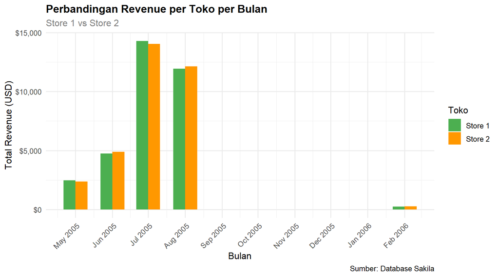

Perbandingan Revenue per Toko

```r
ggplot(df_toko, aes(x = bulan, y = total_revenue, fill = store_id)) +
  geom_bar(stat = "identity", position = "dodge", width = 20) +
  scale_y_continuous(labels = dollar_format(prefix = "$")) +
  scale_x_date(date_labels = "%b %Y", date_breaks = "1 month") +
  scale_fill_manual(values = c("Store 1" = "#4CAF50", "Store 2" = "#FF9800")) +
  labs(
    title    = "Perbandingan Revenue per Toko per Bulan",
    subtitle = "Store 1 vs Store 2",
    x        = "Bulan",
    y        = "Total Revenue (USD)",
    fill     = "Toko",
    caption  = "Sumber: Database Sakila"
  ) +
  theme_minimal(base_size = 12) +
  theme(
    plot.title    = element_text(face = "bold", size = 14),
    plot.subtitle = element_text(color = "gray50"),
    axis.text.x   = element_text(angle = 45, hjust = 1)
  )
```

### 3.5.3 Hubungan Frekuensi Rental vs Total Spending

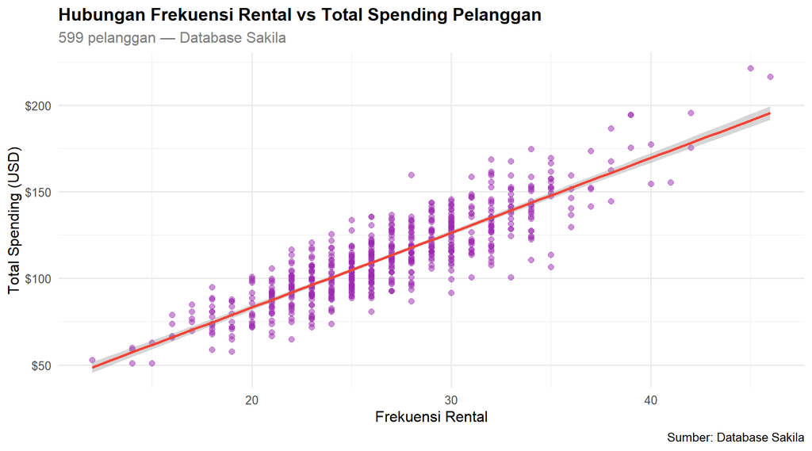

Hubungan Frekuensi Rental vs Total Spending

```r
ggplot(df_customer, aes(x = frekuensi, y = total_spending)) +
  geom_point(alpha = 0.5, color = "#9C27B0", size = 2) +
  geom_smooth(method = "lm", color = "#F44336", se = TRUE) +
  scale_y_continuous(labels = dollar_format(prefix = "$")) +
  labs(
    title    = "Hubungan Frekuensi Rental vs Total Spending Pelanggan",
    subtitle = "599 pelanggan — Database Sakila",
    x        = "Frekuensi Rental",
    y        = "Total Spending (USD)",
    caption  = "Sumber: Database Sakila"
  ) +
  theme_minimal(base_size = 12) +
  theme(
    plot.title    = element_text(face = "bold", size = 14),
    plot.subtitle = element_text(color = "gray50")
  )
```

Scatter plot menunjukkan pola **hubungan linear positif yang kuat** antara frekuensi rental dan total spending. Titik-titik data tersebar cukup rapat di sekitar garis regresi, mengindikasikan bahwa semakin sering pelanggan menyewa, semakin besar pula total pengeluarannya. Hal ini akan dikonfirmasi secara statistik pada analisis regresi berikutnya.

## 3.6 Analisis Statistik

### 3.6.1 Statistik Deskriptif

```r
summary(df_revenue[, c("total_revenue", "jumlah_transaksi", "rata_transaksi")])
```

```
##  total_revenue     jumlah_transaksi rata_transaksi
##  Min.   :  514.2   Min.   : 182     Min.   :2.825
##  1st Qu.: 4823.4   1st Qu.:1156     1st Qu.:4.167
##  Median : 9629.9   Median :2311     Median :4.173
##  Mean   :13481.3   Mean   :3209     Mean   :3.925
##  3rd Qu.:24070.1   3rd Qu.:5686     3rd Qu.:4.228
##  Max.   :28368.9   Max.   :6709     Max.   :4.233
```

```r
summary(df_customer[, c("frekuensi", "total_spending", "recency")])
```

```
##    frekuensi     total_spending      recency
##  Min.   :12.00   Min.   : 50.85   Min.   :  0.0
##  1st Qu.:23.00   1st Qu.: 94.78   1st Qu.:  0.0
##  Median :26.00   Median :110.73   Median :175.0
##  Mean   :26.78   Mean   :112.53   Mean   :129.3
##  3rd Qu.:30.00   3rd Qu.:128.71   3rd Qu.:175.7
##  Max.   :46.00   Max.   :221.55   Max.   :181.6
```

### 3.6.2 Regresi Linear Sederhana

Regresi linear sederhana digunakan untuk menguji apakah frekuensi rental berpengaruh signifikan terhadap total spending pelanggan. Model yang digunakan adalah:

$$\hat{Y} = \beta_0 + \beta_1 X +
\varepsilon$$

Di mana:

- $\hat{Y}$ = prediksi total spending pelanggan
- $\beta_0$ = intercept (nilai spending saat frekuensi = 0)
- $\beta_1$ = koefisien pengaruh frekuensi rental
- $X$ = frekuensi rental
- $\varepsilon$ = error/residual

```r
model_regresi <- lm(total_spending ~ frekuensi, data = df_customer)
summary(model_regresi)
```

```
##
## Call:
## lm(formula = total_spending ~ frekuensi, data = df_customer)
##
## Residuals:
##     Min      1Q  Median      3Q     Max
## -41.386  -8.391  -0.074   8.431  41.936
##
## Coefficients:
##             Estimate Std. Error t value Pr(>|t|)
## (Intercept) -3.22174    2.72462  -1.182    0.237
## frekuensi    4.32164    0.09992  43.249   <2e-16 ***
## ---
## Signif. codes:  0 '***' 0.001 '**' 0.01 '*' 0.05 '.' 0.1 ' ' 1
##
## Residual standard error: 12.49 on 597 degrees of freedom
## Multiple R-squared:  0.7581, Adjusted R-squared:  0.7577
## F-statistic:  1871 on 1 and 597 DF,  p-value: < 2.2e-16
```

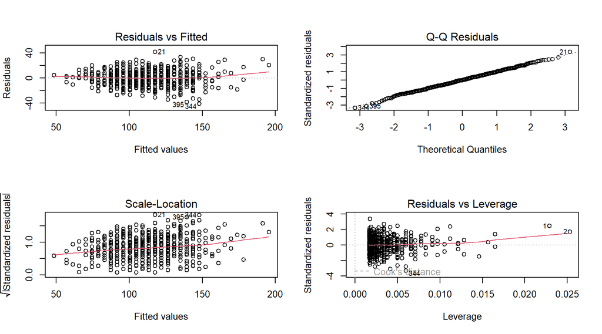

```r
par(mfrow = c(2, 2))
plot(model_regresi)
```

```r
par(mfrow = c(1, 1))
```

Persamaan regresi yang dihasilkan adalah $\hat{Y} = -3{,}22 + 4{,}32X$. Hasil analisis regresi menunjukkan beberapa temuan penting. Pertama, **koefisien frekuensi** ($\beta_1 = 4{,}32$) bermakna bahwa setiap penambahan 1 kali rental, total spending pelanggan meningkat rata-rata sebesar $4,32. Kedua, **intercept** ($\beta_0 = -3{,}22$, $p = 0{,}237$) tidak signifikan secara statistik, yang wajar karena pelanggan dengan frekuensi 0 memang tidak memiliki spending. Ketiga, **p-value** untuk koefisien frekuensi sangat kecil ($< 2{,}2 \times 10^{-16}$), membuktikan bahwa frekuensi rental berpengaruh **sangat signifikan** terhadap total spending. Keempat, nilai **R-squared sebesar 0,7581** menunjukkan bahwa 75,81% variasi total spending dapat dijelaskan oleh frekuensi rental — hubungan yang sangat kuat secara statistik.

### 3.6.3 K-Means Clustering

K-Means Clustering digunakan untuk mengelompokkan pelanggan berdasarkan tiga variabel: frekuensi rental, total spending, dan recency. Fungsi objektif yang diminimalkan adalah:

$$J = \sum_{k=1}^{K} \sum_{x_i \in C_k} \|
x_i - \mu_k \|^2$$

Di mana:

- $K$ = jumlah cluster
- $C_k$ = himpunan observasi dalam cluster $k$
- $\mu_k$ = centroid cluster $k$
- $\|x_i - \mu_k\|^2$ = jarak kuadrat Euclidean dari titik $x_i$ ke centroid $\mu_k$

#### 3.6.3.1 Penentuan Jumlah Cluster Optimal

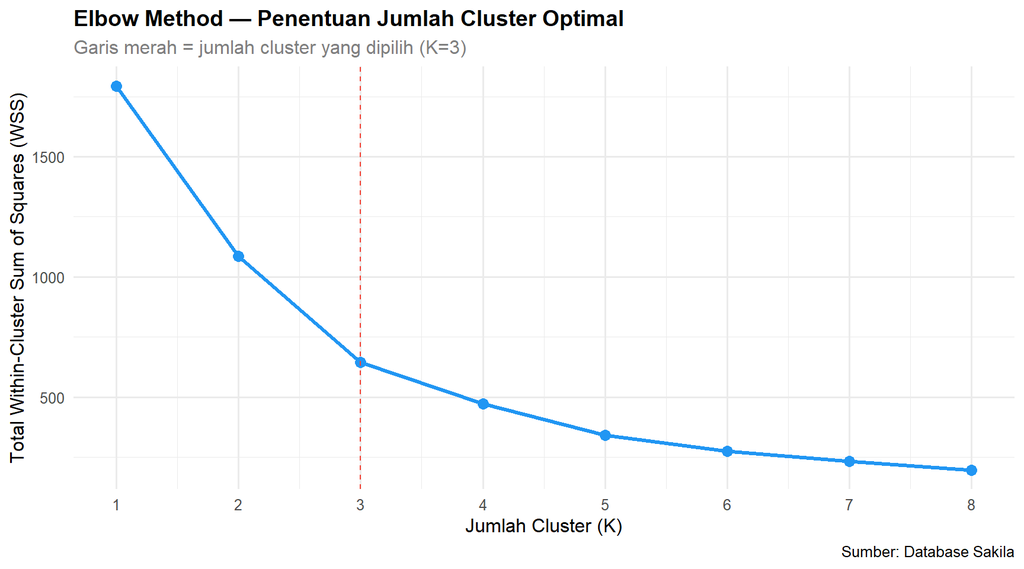

Elbow Method

```r
set.seed(42)
wss <- sapply(1:8, function(k) {
  kmeans(df_cluster, centers = k, nstart = 25)$tot.withinss
})

elbow_df <- data.frame(k = 1:8, wss = wss)

ggplot(elbow_df, aes(x = k, y = wss)) +
  geom_line(color = "#2196F3", linewidth = 1.2) +
  geom_point(color = "#2196F3", size = 3) +
  geom_vline(xintercept = 3, linetype = "dashed", color = "#F44336") +
  scale_x_continuous(breaks = 1:8) +
  labs(
    title    = "Elbow Method — Penentuan Jumlah Cluster Optimal",
    subtitle = "Garis merah = jumlah cluster yang dipilih (K=3)",
    x        = "Jumlah Cluster (K)",
    y        = "Total Within-Cluster Sum of Squares (WSS)",
    caption  = "Sumber: Database Sakila"
  ) +
  theme_minimal(base_size = 12) +
  theme(
    plot.title    = element_text(face = "bold", size = 14),
    plot.subtitle = element_text(color = "gray50")
  )
```

Grafik Elbow Method menunjukkan bahwa penurunan nilai WSS mulai melandai secara signifikan setelah K=3. Penambahan cluster di atas 3 tidak memberikan pengurangan WSS yang berarti, sehingga **K=3 dipilih sebagai jumlah cluster optimal**.

#### 3.6.3.2 Hasil Clustering

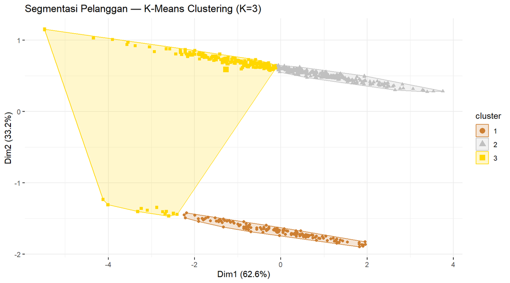

Hasil K-Means Clustering

```r
set.seed(42)
kmeans_result <- kmeans(df_cluster, centers = 3, nstart = 25)

df_customer$cluster <- factor(kmeans_result$cluster,
                               labels = c("Bronze", "Silver", "Gold"))

fviz_cluster(kmeans_result,
             data         = df_cluster,
             geom         = "point",
             ellipse      = TRUE,
             ellipse.type = "convex",
             palette      = c("#CD7F32", "#C0C0C0", "#FFD700"),
             ggtheme      = theme_minimal(),
             main         = "Segmentasi Pelanggan — K-Means Clustering (K=3)")
```

```r
df_customer %>%
  group_by(cluster) %>%
  summarise(
    jumlah_pelanggan = n(),
    rata_frekuensi   = round(mean(frekuensi), 2),
    rata_spending    = round(mean(total_spending), 2),
    rata_recency     = round(mean(recency), 2)
  ) %>%
  kable(
    caption   = "Ringkasan Statistik per Cluster",
    col.names = c("Cluster", "Jumlah Pelanggan", "Rata-rata Frekuensi",
                  "Rata-rata Spending ($)", "Rata-rata Recency (hari)")
  ) %>%
  kable_styling(bootstrap_options = c("striped", "hover", "condensed"),
                full_width = FALSE)
```

Ringkasan Statistik per Cluster

| Cluster | Jumlah Pelanggan | Rata-rata Frekuensi | Rata-rata Spending ($) | Rata-rata Recency (hari) |
| --- | --- | --- | --- | --- |
| Bronze | 146 | 26.84 | 109.19 | 0.0 |
| Silver | 252 | 22.98 | 95.32 | 175.7 |
| Gold | 201 | 31.51 | 136.54 | 165.0 |

Hasil K-Means Clustering dengan K=3 berhasil mengelompokkan 599 pelanggan ke dalam tiga segmen dengan karakteristik perilaku transaksi yang berbeda-beda.

**🥉 Segmen Bronze (146 pelanggan)** terdiri dari pelanggan dengan rata-rata frekuensi rental 26,84 kali dan total spending rata-rata $109,19. Yang paling menonjol adalah nilai recency sebesar **0 hari**, yang berarti seluruh pelanggan dalam kelompok ini melakukan transaksi terakhirnya pada Februari 2006 — periode paling akhir dalam data. Dengan kata lain, Bronze adalah satu-satunya segmen yang **masih aktif** saat data diambil. Meski demikian, frekuensi dan spending-nya berada di posisi menengah, mengindikasikan bahwa pelanggan Bronze adalah tipe pelanggan kasual yang kembali aktif namun belum menunjukkan komitmen transaksi yang tinggi.

**🥈 Segmen Silver (252 pelanggan)** merupakan kelompok **terbesar** dengan jumlah 252 pelanggan atau sekitar 42% dari total pelanggan. Rata-rata frekuensi rental hanya 22,98 kali dengan total spending rata-rata $95,32 — keduanya merupakan nilai **terendah** di antara ketiga segmen. Nilai recency sebesar 175,7 hari menunjukkan pelanggan Silver terakhir bertransaksi sekitar Agustus 2005, yang berarti sudah hampir 6 bulan tidak aktif. Kombinasi frekuensi rendah, spending rendah, dan recency tinggi menjadikan Silver sebagai segmen **pelanggan yang berisiko churn** atau bahkan sudah churn. Meskipun demikian, karena jumlahnya paling besar, segmen ini menyimpan potensi revenue yang signifikan jika berhasil direaktivasi.

**🥇 Segmen Gold (201 pelanggan)** memiliki rata-rata frekuensi rental tertinggi sebesar 31,51 kali dan rata-rata total spending tertinggi sebesar $136,54, menjadikannya segmen **paling bernilai secara bisnis**. Recency rata-rata 165,0 hari menunjukkan transaksi terakhir sekitar Agustus 2005 — tidak aktif dalam periode terkini, namun rekam jejak transaksi historisnya sangat kuat. Pelanggan ini adalah tipe **loyal customer** yang pernah sangat terlibat dengan layanan toko, sehingga peluang reaktivasi jauh lebih besar dibanding segmen lainnya.

# 4 Kesimpulan

**Ringkasan temuan utama:**

1. **Tren Revenue** — Revenue mengalami lonjakan signifikan pada Juli 2005 kemudian sedikit menurun di Agustus 2005, dengan jeda panjang hingga Februari 2006 yang perlu diinvestigasi lebih lanjut.
2. **Perbandingan Toko** — Store 1 dan Store 2 menunjukkan performa yang relatif seimbang sepanjang periode pengamatan, tanpa dominasi signifikan dari salah satu toko.
3. **Regresi Linear** — Frekuensi rental terbukti berpengaruh sangat signifikan terhadap total spending pelanggan ($p < 0{,}001$) dengan $R^2 = 0{,}758$.
4. **Segmentasi Pelanggan** — Terdapat 3 segmen pelanggan dengan karakteristik berbeda: Bronze (aktif, spending menengah), Silver (tidak aktif, spending rendah), dan Gold (tidak aktif, spending tinggi/loyal).

## 4.1 Rekomendasi Bisnis

- **Bronze** — Manfaatkan keaktifan terkini pelanggan dengan strategi *upselling* dan *cross-selling* seperti rekomendasi film premium atau paket berlangganan guna mendorong peningkatan frekuensi dan spending.
- **Silver** — Jalankan **kampanye reaktivasi** melalui diskon khusus, voucher, atau notifikasi promosi yang dipersonalisasi untuk menarik kembali pelanggan yang sudah lama tidak aktif, mengingat segmen ini adalah yang terbesar.
- **Gold** — Prioritaskan program **loyalitas eksklusif** seperti membership premium atau reward poin untuk mempertahankan dan mengaktifkan kembali pelanggan paling profitable ini.
- **Operasional** — Investigasi penyebab gap transaksi antara Agustus 2005 dan Februari 2006 untuk mencegah kejadian serupa di masa mendatang.